# 01. 벡터와 벡터의 기본연산

```python
import numpy as np
import matplotlib.pyplot as plt


import matplotlib_inline.backend_inline
matplotlib_inline.backend_inline.set_matplotlib_formats('svg')
plt.rcParams.update({'font.size':14})
```

## 01.01. `NumPy`

### 벡터

- 수를 순서대로 나열한 객체
  - 전통적인 선형대수학에서는 함수와 같은 다른 수학적 대상을 가질 수 있음

#### 벡터의 특징

- 차원 (dimension) : 벡터가 가진 원소의 수
- 방향 (orientation) : 벡터가 열 방향 (높이 세워진)인지 행 방향 (길고 평평하게 누운)인지를 나타냄
  - 종종 $\mathbb{R}^N$으로 표현 ($\mathbb{R}:\text{실수(Real number)의 집합}\;\;\mathbb{C} :\text{복소수 (Complex number)의 집합}$

    2개의 원소가 있는 벡터 : $\mathbb{R}^2$

$$x = \begin{bmatrix}1\\4\\5\\6 \end{bmatrix}\;\;\ y= \begin{bmatrix}.3\\-7 \end{bmatrix}\;\;z=\begin{bmatrix}1&4&5&6 \end{bmatrix}$$

- $x$는 4차원 열벡터, $y$는 2차원 열벡터, $z$는 4차원 행벡터
- 파이썬에서 벡터 또는 행렬의 차원의 수는 개체를 출력하는데 사용되는 기하학적 차원의 수
  - 모든 벡터는 벡터가 가진 원소의 수 (수학적 차원)에 상관없이 NumPy에서 2차원 배열로 간주
  - 특정 방향이 없는 수 나열은 원소 수에 상관없이 파있너에서 1차원 배열
  - 수학적 차원, 즉 벡터의 원소 수는 파이썬에서 벡터의 '길이'와 '모양'으로 표현
- **선형대수학에서 보통 벡터에 아무런 표시가 없다면 열 방향이라고 가정**

### 벡터 생성

- **방향이 부여된 벡터는 모두 행과 열을 가지는 2차원 배열**

#### 방향이 없는 배열

```python
asArray = np.array([1,2,3])
```

```python
asArray
```

```
array([1, 2, 3])
```

```python
asArray.shape
```

```
(3,)
```

#### 행벡터

```python
rowVec = np.array([ [1,2,3] ])
```

```python
rowVec
```

```
array([[1, 2, 3]])
```

```python
rowVec.shape
```

```
(1, 3)
```

#### 열벡터

```python
colVec = np.array([ [1],[2],[3] ])
```

```python
colVec
```

```
array([[1],
       [2],
       [3]])
```

```python
colVec.shape
```

```
(3, 1)
```

### 벡터의 기하학적 해석

- **벡터의 대수학적 해석: 순서대로 나열된 수 목록 (ordered list of numbers)** $\rightarrow$ 데이터 과학에서 사용
- **벡터의 기하학적 해석 : 특정 길이 (또는 크기, magnitude)와 방향 (angle, direction : 양의 $x$축을 기준으로 계산됨)을 가진 직선** $\rightarrow$ 물리학과 공학에서 사용

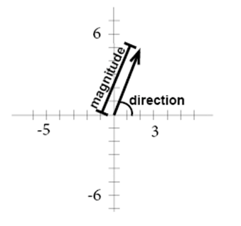

- **벡터의 두 점은 꼬리 (시작하는 곳)과 머리 (끝나는 곳)라고 불리며, 일반적으로 머리는 꼬리와 명확히 구분하기 위해 화살표를 가짐**

#### 벡터 $\neq$ 기하학적 좌표가 인코딩된 형태

- **벡터가 원점에서 시작될 때는 일치 (기준 위치, standard position)**
- 아래의 화살표는 모두 동일한 벡터
- **하나의 화살푠는 기준 위치의 벡터로써, 꼬리가 원점에 있고 머리는 기하학적 좌표를 가르킴**

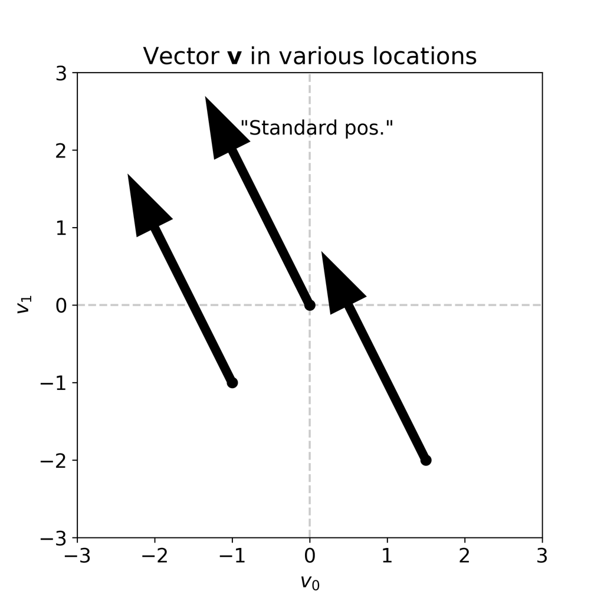

## 01.02. 벡터 연산

### 벡터의 연산 (Operation)

#### 벡터의 덧셈/뺄셈

- **벡터의 덧셈/뺄셈은 동일한 차원을 갖는 벡터끼리만 가능**

$$\begin{bmatrix}4\\5\\6 \end{bmatrix} + \begin{bmatrix}10\\20\\30 \end{bmatrix} = \begin{bmatrix} 14\\25\\36 \end{bmatrix}$$

```python
v = np.array([4, 5, 6])
w = np.array([10, 20 ,30])
vPlusW = v+w
vMinusW = v-w

print(v)
print(w)
print(vPlusW)
print(vMinusW)
```

```
[4 5 6]
[10 20 30]
[14 25 36]
[ -6 -15 -24]
```

### 벡터 덧셈/뺄셈의 기하학적 해석

#### 기하학적으로 벡터의 더한 결과는 첫 번째 벡터의 꼬리와 두 번째 벡터의 머리를 이은 선

[figure not shown]

#### 기하학적으로 벡터를 빼는 것은 두 번째 벡터의 머리에서 첫 번째 벡터의 머리로 가는 선

- $A-B = A + (-B)$
- 벡터 뺄셈은 직교벡터 분해의 기초이며, 선형 최소제곱법의 기초

[figure not shown]

### 스칼라-벡터 곱셈

#### 스칼라 (Scalar)

- 벡터나 행렬에 포함된 숫자가 아닌 수 그 자체

$$\lambda=4,\;\;w=\begin{bmatrix} 9\\4\\1\end{bmatrix},\;\;\lambda w= \begin{bmatrix} 36\\16\\4\end{bmatrix}$$

```python
s = 4

b = np.array([9,4,1])

print(s*b)
```

```
[36 16  4]
```

#### 스칼라-벡터 곱셈의 기하학적 해석

- **스칼라는 벡터의 뱡향을 바꾸지 않고 크기만 조정**
- **하지만, 스칼라가 음수일 때 벡터의 방향이 180도 회전**
  - **'벡터는 원점을 통과해서 양방향의 무한대로 가는 무한히 긴 선을 의미'한다는 해석아래,**

    **회전된 벡터는 여전히 동일한 무한한 선을 가리키므로, 음의 스칼라가 방향을 바꾼 것이 아님**

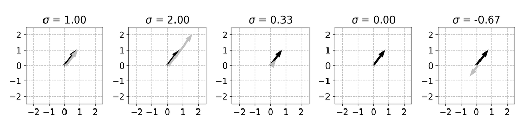

### 영벡터 (Zero vector)

- 모든 원소가 0

### 스칼라-벡터 덧셈

#### 선형대수학적으로 벡터와 스칼라 간의 덧셈을 불가능

#### 파이썬에서는 가능

```python
s = 3.5

print(v)
print(s+v)
```

[output not shown]

### 전치

- **각 행렬 원소의 (행, 열) 인덱스를 맞바꿈**

$$m^T_{ij}=m_{ji}$$

- 벡터를 두 번 전치하면, 벡터는 원래의 벡터로 돌아옴 ($v^{TT}=v$)

```python
r = np.array([ [1,2,3] ])
```

[output not shown]

```python
print(r), print(' ')

print(r.T), print(' ')

print(r.T.T)
```

```
[[1 2 3]]

[[1]
 [2]
 [3]]

[[1 2 3]]
```

### 파이썬에서 벡터 브로드캐스팅

- **브로드캐스팅 연산은 현대 컴퓨터 기반 선형대수학에서만 존재**

  **전통적인 선형대수학 교과서에는 없음**
- **본질적으로 한 벡터를 다른 벡터의 각 원소로 연산을 여러번 반복하는 것**

```python
v = np.array([[1, 2, 3]]).T # 열 벡터
w = np.array([[10, 20]]) # 행 벡터
print(v)
print(w)
```

```
[[1]
 [2]
 [3]]
[[10 20]]
```

$$\begin{bmatrix}1&1\\2&2\\3&3 \end{bmatrix} + \begin{bmatrix}10&20\\10&20\\10&20 \end{bmatrix}$$

```python
v + w
```

```
array([[11, 21],
       [12, 22],
       [13, 23]])
```

## 01.03. 벡터 크기와 단위벡터

### 벡터 크기 (노름)

- **벡터의 크기 (기하학적 길이, 노름, Norm) : 벡터의 꼬리부터 머리까지의 거리**
  - 표준 유클리디안 거리 공식을 사용하여 계산

$$||v|| = \sqrt{\sum^n_{i=1} v^2_i}$$

#### `np.linalg.norm()`

```python
v = np.array([1, 2, 3, 7, 8, 9])
v_mag = np.linalg.norm(v)
```

```python
print(v_mag)
```

```
14.422205101855956
```

### 단위벡터

- **기학적 길이가 1인 벡터**

$$||v||=1$$

#### 단위벡터 생성

- **벡터 노름의 역수를 스칼라 곱셈**

$$\hat{v}=\frac{1}{||v||}v$$

- **대부분의 비단위벡터는 연관된 단위벡터를 가짐**

  (영벡터는 연관된 단위벡터를 계산할 수 없음)

## 01.04. 내적

- 내적 (dot product, 점곱, 스칼라곱)은 합성곱 (convolution), 상관관계 (correlation), 푸리에 변환 (Fourier transform) 행렬 곱셈, 선형 특징 추출, 신호 필터링 등 다양한 알고리즘의 기본
- **내적은 두 벡터 사이의 유사성(similarity), 또는 매핑 (mapping)의 척도로 해석 가능**

  (두 변수 사이의 정규화된 내적 = 피어슨 상관계수)
- **동일한 차원의 두 벡터사이에서만 계산이 성립하며,**

  **두 벡터에서 대응되는 원소끼리 곱한 다음 모든 결과를 더함**

$$a^Tb = a \cdot b = \sum^n_{i=1}a_i b_i$$

#### `np.dot()`

```python
v = np.array([1, 2, 3, 4])
w = np.array([5, 6, 7, 8])
np.dot(v, w)
```

```
70
```

#### 벡터에 스칼라를 곱하면, 내적도 그만큼 거짐

```python
s = 10
np.dot(s*v, w)
```

```
700
```

```python
s = -1
np.dot(s*v, w)
```

```
-70
```

### 내적의 분배법칙

- **수학의 분배법칙 : $a(b+c)=ab+ac$**
- **내적의 분배법칙**

$$a^T(b+c) = a^Tb+a^Tc$$

#### 즉, 벡터 덧셈의 내적은 벡터-내적의 덧셈과 동일

```python
v = np.array([ 0,1,2 ])
w = np.array([ 3,5,8 ])
u = np.array([ 13,21,34 ])
```

- 벡터 덧셈의 내적

```python
res1 = np.dot( v, w+u )
res1
```

```
110
```

- 벡터-내적의 덧셈

```python
res2 = np.dot( v,w ) + np.dot( v,u )
res2
```

```
110
```

### 내적의 기하학적 해석

- **두 벡터의 크기(노름)를 곱하고, 두 벡터 사이의 각도에서 코사인값만큼 크기를 늘리는 것** ([증명](https://cynthis-programming-life.tistory.com/entry/%EB%B2%A1%ED%84%B0-%EB%82%B4%EC%A0%81-%EA%B3%B5%EC%8B%9D-%EC%9C%A0%EB%8F%84))

$$\alpha = cos(\theta_{y, w})\;||v||\;||w||$$

- 벡터의 크기는 양수(0 벡터는 ||**0**||=0으로 제외)이며, 코사인 값은 -1과 +1 사이의 값

  **$\rightarrow$ 이는 내적의 부호가 전적으로 두 벡터 사이의 기하학적 관계로 결정됨을 의미**
1. 예각 ($\theta < 90$) $\;\;\rightarrow\;\;$ $cos(\theta)>0,\;\;\alpha > 0$
2. 둔각 ($\theta > 90$) $\;\;\rightarrow\;\;$ $cos(\theta)<0,\;\;\alpha < 0$
3. 직각 ($\theta = 90$) $\;\;\rightarrow\;\;$ $cos(\theta)=0,\;\;\alpha = 0$ **(서로 직교하는 벡터의 내적은 0)**
4. 공선 ($\theta = 0$) $\;\;\rightarrow\;\;$ $cos(\theta)=1,\;\;\alpha = |a|\;|b|$
5. 공선 ($\theta = 180$) $\;\;\rightarrow\;\;$ $cos(\theta)=-1,\;\;\alpha = -|a|\;|b|$

[figure not shown]

## 01.05. 벡터의 곱셈

### 아다마르곱 (Hadamard product)

- **차원이 같은 두 벡터에 대해서, 두 벡터의 대응되는 각 원소를 곱**

```python
a = np.array([5, 4, 8, 2])
b = np.array([1.0, .5, 1, 2])
a * b
```

```
array([5., 2., 8., 4.])
```

### 외적

- **외적 행렬 ($vw^T$)의 각 행은 행벡터 스칼라에 대응되는 열벡터 원소를 곱한 것**

  **각 열은 열벡터 스칼라에 대응되는 행벡터 원소를 곱한 것**

  (계수 (rank) -1 행렬)

$$\begin{bmatrix}a\\b\\c \end{bmatrix} \begin{bmatrix}d &e \end{bmatrix} = \begin{bmatrix}ad&ac\\bd&bc\\cd&ce \end{bmatrix}$$

- **외적은 스칼라 대신 행렬을 생성**
- **두 벡터는 차원이 달라도 외적 연산이 가능**

## 01.06. 직교벡터 분해

- **직교벡터 분해 : 하나의 벡터를 두 개의 벡터로 분해**

  **하나는 기준벡터와 직교하고 다른 하나는 기준벡터와 평행**
- 직교벡터 분해는 통계에서의 그람-슈미트 과정 (Gram-Schmidt Process)와 QR분해에 직접적 연관성 존재

### 직교 투영법 (Orthognal Projection)

- **두 벡터 $a$와 $b$가 존재할 때, $b$에서 $a$의 머리와 가장 가까운 점을 탐색**

  **즉, 투영 거리가 최소가 되도록 벡터 $a$를 $b$에 투영**

  **$\rightarrow$ $b$의 크기를 줄인 $a_1$이 됨**

  **$\rightarrow$ $b$가 $a_1$이 되게하는 스칼라 $\beta$를 탐색**
- $a_1 + a_2=a$이 성립하며, $a_1$이 $a_2$와 직교

  $\rightarrow$ 두 벡터 사이의 내적은 0

$$b^T(a_2)=0$$

- $a_2$는 $a-a_1 = a- \beta b$이기 때문에,

  $b$가 $a_1$이 되게하는 스칼라 $\beta$를 찾기 위하여

$$b^Ta - \beta b^Tb = 0$$$$\beta b^Tb=b^Ta$$$$\beta = \frac{b^Ta}{b^Tb}=\frac{a^Tb}{b^Tb}=\frac{a^Tb}{||b||}$$

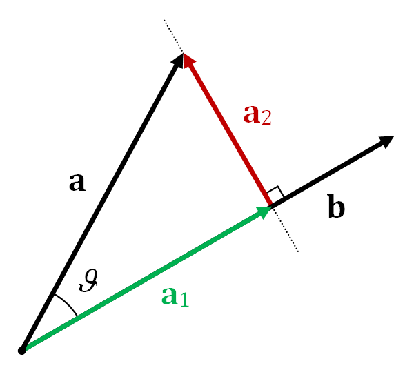

### 직교벡터 분해

- **'목표벡터'$a$와 '기준벡터' $b$라는 두 개의 벡터를 가정**
- **직교벡터 분해의 목적은 목표벡터를 두 개의 다른 벡터 '수직성분 ($a \perp_b$)'와 '평행성분 ($a || _b$)'로 분해 하는 것**
  1. **두 벡터의 합은 목표벡터가 되어야 하며**
  2. **하나의 벡터는 기준벡터와 직교하지만 다른 벡터는 기준벡터와 평행**

#### 평행성분은 직교 투영법의 원리를 통하여

$$a || _b = \beta b = b \frac{a^T b}{b^T b}=\frac{a^Tb}{||b||}$$

#### 수직성분은

$$a \perp_b\; + \;a || _b = a$$

를 이용하여

$$a \perp_b = a - b \frac{a^T b}{b^T b}=\frac{a^T b}{||b||}$$

#### 평행성분과 수직성분은 직교하기에 내적은 0

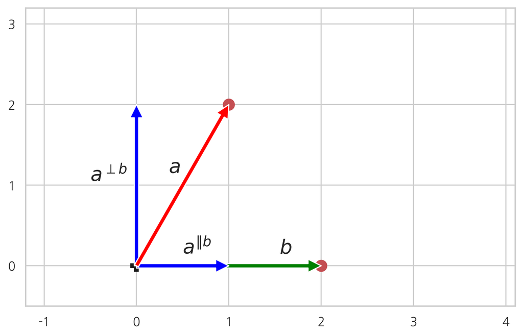